# 第10回 Pandas

プログラミング演習Ⅱ

佐藤 秀保

sato0035@toyo.jp

## 先週までの内容

- Numpyにおける；
- **抽出**：インデックス/スライシングアクセス
- **代入**：インデックス/スライシングアクセス
- **演算**：要素ごとに可
- ブロードキャスト：長さが1の次元を自動的に引き伸ばし，形の合うように演算・代入
- **ユニバーサル関数**：各要素に特定の演算を適用
- **記述統計量**：`numpy.sum` / `max` / `min` / `mean`メソッド（引数が`0`なら列，`1` なら行）

## 準備

1. [Colab](https://colab.research.google.com/?hl=ja).にアクセス
2. 左下「ノートブックを新規作成」
3. 左上のノートブック名を「lec10」などに変更
4. 右側に「リリースノート」が出る場合は×で消す

## [再掲] データの種類

- R

| 次元数 | 同一の型 | 異なる型OK |
| --- | --- | --- |
| 1 | アトミックベクトル | リスト |
| 2 | 行列 | データフレーム |
| 3以上 | 配列 |  |

## [再掲] データの種類

- Python

| 次元数 | 同一の型 | 異なる型OK |
| --- | --- | --- |
| 1 | `numpy.ndarray` | リスト、タプル |
| 2 | `numpy.ndarray` | `pandas.DataFrame` |
| 3以上 | `numpy.ndarray` |  |

※ほかに「辞書」など（Rでは名前付きリストに近い）

## Pandasとは

- Pandas（**pan**el **da**taに由来）
- 表形式データを扱うためのパッケージ
- **用途：**
  - データ読込（CSV・Excelなど）
  - データ抽出・整形・結合
  - 集計・グループ分析
- **特徴：**
  - tidyverse に近い操作が可能
  - Pythonでのデータ分析の**基本スキル**

### `DataFrame`とは

- `DataFrame`：行 × 列からなる「表形式データ」
- 異なるデータの型OK，２次元
- `pandas.DataFrame`関数で生成

```python
#pandasパッケージの読込，aliasは通常pd
import pandas as pd

# DataFrame の生成（辞書 → 表形式へ）
df = pd.DataFrame({
    "name": ["A", "B", "C"],
    "score": [80, 90, 70],
    "passed": [True, True, False]
})
print(df)
```

### `Series`

- DataFrame の1列が`Series`
- その中身は`numpy.ndarray`に**インデックス（行ラベル）** をつけたもの
- つまり，同一の型

```python
# 1列（Series）を取り出す
s = df["score"]
print(s)
#左の0 1 2がインデクッス（行ラベル）
#80 90 70がSeries
```

## `pandas.DataFrame` vs Rの`data.frame`

| 観点 | **`pandas.DataFrame`** | **Rの`data.frame`** |
| --- | --- | --- |
| 形 | 2次元（行 × 列） | 2次元（行 × 列） |
| 列の正体 | **`Series`の集合** | **ｱﾄﾐｯｸﾍﾞｸﾄﾙの集合** |
| 列内の型 | 列ごとに同一 | 列ごとに同一 |
| 元データ型 | **`numpy.ndarray`に依存** | **ｱﾄﾐｯｸﾍﾞｸﾄﾙに依存** |
| 行ラベル | **`index`を持つ** | `rownames`を持つ |
| 列ラベル | `column name`を持つ | `names`を持つ |
| 作り方 | `pd.DataFrame({})` | `data.frame()` |

### `DataFrame` の型

| 型名 | 説明 |
| --- | --- |
| `int64` | 整数（64-bit） |
| `float64` | 倍精度小数（64-bit） |
| `bool` | 論理値 |
| `object` | 文字列など |
| `string` | 文字列（`pandas`専用） |
| `categorical` | カテゴリ型（Rのfactorに近い） |
| `Int64` / `Int32` | 欠損値（NA）が扱える整数 |

- 元データは`ndarray`だが`pandas`の様々な機能が使えるように専用の型

### 演習

- 商品名のリスト`list_names`，
- 売上価格のリスト`list_prices`，
- 売上数量のリスト`list_quantities`

を列とする`pandas.DataFrame`「`df_uriage`」を生成し`print`関数で表示せよ．

- ただし，以下のコードを読み込み，列名はそれぞれ`product_names`，`prices`，`quantities` とする．

```python
import pandas as pd
list_names = ["milk_A", "milk_B", "milk_C"]
list_prices = [150, 200, 250]
list_quantities = [20, 18, 13]
```

## 外部データの読込

- 通常，既にあるエクセルデータを読み込ませ，そのデータを加工・分析
- ACEにアップロードのエクセルファイル「`syokudo_data1`」を読み込む
  - 朝霞キャンパス食堂の日別売上データ（2025年6月1～17日）

### 外部データの読込方法（Google Colab）

1. **ローカルにエクセルファイルを保存**
   - 「`syokudo_data1`」をACEから適当な場所に保存
2. **エクセルファイルをColab上にアップロード**

```python
from google.colab import files
uploaded = files.upload()
```

- 「ファイル選択」
- 1の保存場所で「`syokudo_data1`」を選択し「開く」
3. **アップロードしたエクセルファイルを読込**

```python
df_syokudo = pd.read_excel("syokudo_data1.xlsx")
print(df_syokudo)
```

※`head`メソッドで上から５行のみ確認

```python
df_syokudo.head()
```

## 抽出

### 整数での抽出・ラベルでの抽出

- 整数でのアクセス：`iloc`（**i**nteger **loc**ation）

```python
print(df_syokudo.iloc[0,0]) #左上1つ
#スライシング
print(df_syokudo.iloc[0:2,0:2]) #左上4つ
```

- ラベルでのアクセス：`loc`（label-based **loc**ation）

```python
print(df_syokudo.loc[0,"日付"]) #左上1つ
#スライシング
print(df_syokudo.loc[0:1,["日付","純売上"]]) #左上4つ
```

※`loc`は行ラベルを名指しで指定しているためスライシングの**終点も含まれる**

- 行ラベルを数値から文字に変更，再度ラベルでアクセス

```python
#行ラベル「0 1」を「1行目 2行目」に変更
df_temp = df_syokudo.rename(index={0:"1行目",1:"2行目"})
df_temp.head()
```

```python
#locでの抽出
print(df_temp.loc[["1行目","2行目"],["日付","純売上"]])　#左上4つ
```

※つまり,`df_syokudo.loc[0:1,["日付","純売上"]])`の`0:1`はラベル名なので終点も含まれている．

### 列の抽出

```python
#ilocで列抽出
print(df_syokudo.iloc[:, 0])      # Seriesとして抽出
print(df_syokudo.iloc[:, [0]])    # DataFrameとして抽出
print(df_syokudo.iloc[:, [0, 2]]) # 複数列
```

```python
#locで列抽出
print(df_syokudo.loc[:, '日付'])         # Seriesとして抽出
print(df_syokudo.loc[:, ['日付']])       # DataFrameとして抽出
print(df_syokudo.loc[:, ['日付', '純売上(税抜)']])# 複数列
```

```python
#列ラベルのリストで列抽出
print(df_syokudo['日付'])         # Seriesとして抽出
print(df_syokudo[['日付']])       # DataFrameとして抽出
print(df_syokudo[['日付', '純売上(税抜)']])# 複数列
```

```python
#簡易アクセス
print(df_syokudo.日付)         # Seriesとして抽出
```

### 列抽出：`pandas` vs R

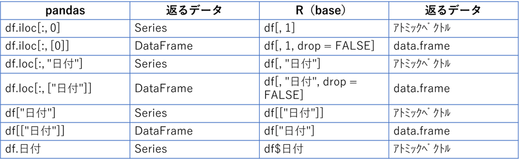

### 行の抽出

```python
#ilocで抽出
print(df_syokudo.iloc[0])          # Seriesとして抽出
print(df_syokudo.iloc[[0]])        # DataFrameとして抽出
print(df_syokudo.iloc[[0, 2]])  # 複数行
```

```python
#locで抽出
print(df_syokudo.loc[0])           # Seriesとして抽出
print(df_syokudo.loc[[0]])         # DataFrameとして抽出
print(df_syokudo.loc[[0, 2]])   # 複数行
```

```python
#条件で抽出
print(df_syokudo[df_syokudo['純売上(税抜)'] > 200000])  # 売上が20万円超の行だけ
print(df_syokudo[df_syokudo['客数'] >= 350])             # 客数が350以上
print(df_syokudo[(df_syokudo['客数'] >= 350) &
                 (df_syokudo['純売上(税抜)'] > 200000)]) # AND条件
```

### `pandas`と`dplyr`

- Rの`tidyverse`にはデータ整形に関わるパッケージ`dplyr`があり，`select`（列抽出），`filter`（行抽出），`mutate`（列追加），`summarise`（集計）など便利な関数が豊富
- Pythonの`pandas`にはそのようなものは無く，`base`（デフォルト）のRの機能程度の使い勝手
- ２次元データの扱いではRが優秀
- 多次元はPythonが強い

### 演習

- 「客数」列が400以上のデータの「日付」列を抽出し，それが何曜日に該当するかカレンダーで調べよ．
- ただし，以下を実行しデータの読込は完了しているものとする．

```python
import pandas as pd
df_syokudo = pd.read_excel("syokudo_data1.xlsx")
df_syokudo.head()
```

## 課題

- ACEの小テスト：「第10回」
- ACEのレポート：「第10回」
  - ノートブックを提出（方法は第１回資料参照）